# Decorrelation-Based SOTA: LGG

Jose Tamez

2024-03-04

# 1 Effect of UPSTM-Based Decorrelation on ML Performance

### 1.0.1 Loading the libraries

```r
library("FRESA.CAD")
library(readxl)
library(igraph)
library(umap)
library(tsne)
library(entropy)

op <- par(no.readonly = TRUE)
pander::panderOptions('digits', 3)
pander::panderOptions('table.split.table', 400)
pander::panderOptions('keep.trailing.zeros',TRUE)
source("C:/Users/jtame/Documents/GitHub/LatentBiomarkers/RMD/DecorrelationCV.R")
```

## 1.1 Material and Methods

About Dataset This dataset is a copy of another Kaggle dataset which can be accessed here: https://www.kaggle.com/c/glioma-radiomics The difference is that I have provided ground truth for the test set (test_GT.csv).

The suffix “omics” in Medical Science is associated with analysis of big sets of features (e.g. Genomics, Proteomics). Radiomics are imaging features (e.g., first order and second order) extracted from Regions of Interest (ROI) in radiology images based on predefined functions and filters. Low grade gliomas (LGG) are a type of brain tumors. Astrocytes and Oligodendrocytes which are two types of brain cells, are considered as origins of LGG. Adult LGG are characterized by different mutations which is important to be correctly identified. With this dataset the goal is to determine if an ROI has 1p19q codeletion (Mutacion=1) or not(Mutacion=0). This plays a key role in predicting patient’s response to chemotherapy and their survival. The dataset provides 640 different radiomics features for each ROI. There are 105 ROIs in the training set and 45 ROIs in the test cohort.

## 1.2 The Data

https://www.kaggle.com/datasets/knamdar/radiomics-for-lgg-dataset?select=test_GT.csv

```r
LGG_Data <- read.csv("~/GitHub/LatentBiomarkers/Data/LGG/train.csv")
LGG_DataTest <- read.csv("~/GitHub/LatentBiomarkers/Data/LGG/test.csv")
LGG_TestGT <- read.csv("~/GitHub/LatentBiomarkers/Data/LGG/test_GT.csv")
LGG_DataTest$Mutacion <- LGG_TestGT$Mutacion

LGG_Data <- rbind(LGG_Data,LGG_DataTest)

rownames(LGG_Data) <- LGG_Data$patientID
LGG_Data$patientID <- NULL

pander::pander(table(LGG_Data$Mutacion))
```

| 0 | 1 |
| --- | --- |
| 54 | 96 |

#### 1.2.0.1 Standarize the names for the reporting

```r
studyName <- "LGG"
dataframe <- LGG_Data
outcome <- "Mutacion"

needScaling <- TRUE
tfrac <- 0.80
nLoops <- 50

IDSample <- FALSE
thro <- 0.8
#cmethod="spearman"
```

## 1.3 CV Analysis and report

### 1.3.1 Libraries

```r
library(xgboost)
library("vioplot")
```

## 1.4 XGB interface

```r
s3xgb <- function(formula=formula,data=NULL,...)
{
  if (inherits(formula, "character"))
    {
        formula <- formula(formula);
    }
    dependent <- all.vars(formula)
    Outcome = dependent[1];

  thexbcol <- colnames(data)[(colnames(data) != Outcome)]
  xbst <- xgboost(data = as.matrix(data[,thexbcol]), label = data[,Outcome],
                max_depth = 30, eta = 0.05, nthread = 12, nrounds = 100,
                objective = "binary:logistic",verbose = 0)
  class(xbst) <- c("S3XBST",class(xbst))
  attr(xbst,"trainnames") <-  thexbcol
  return (xbst)
}
predict.S3XBST <- function(object,...)
{
  parameters <- list(...);
    testData <- parameters[[1]];
    class(object) <- class(object)[2]
  pred <- predict(object,as.matrix(testData[,attr(object,"trainnames")]))
  return(pred)
}
```

## 1.5 SOTA Comparison to XGB, SVM and LASSO

### 1.5.1 XGB

```r
XBOOSTcv <- randomCV(dataframe,outcome,s3xgb,
                        trainFraction = tfrac,
                        repetitions = nLoops,
                        classSamplingType ="Ba")
```

……….10 Tested: 144 Avg. Selected: 0 Min Tests: 1 Max Tests: 9 Mean Tests: 4.444444 . MAD: 0.359798

……….20 Tested: 149 Avg. Selected: 0 Min Tests: 1 Max Tests: 16 Mean Tests: 8.590604 . MAD: 0.3544758

……….30 Tested: 149 Avg. Selected: 0 Min Tests: 2 Max Tests: 23 Mean Tests: 12.88591 . MAD: 0.3527108

……….40 Tested: 150 Avg. Selected: 0 Min Tests: 1 Max Tests: 30 Mean Tests: 17.06667 . MAD: 0.3485492

……….50 Tested: 150 Avg. Selected: 0 Min Tests: 1 Max Tests: 38 Mean Tests: 21.33333 . MAD: 0.3485823

```r
XGBbs <- predictionStats_binary(XBOOSTcv$medianTest,"XGB: CV")
```

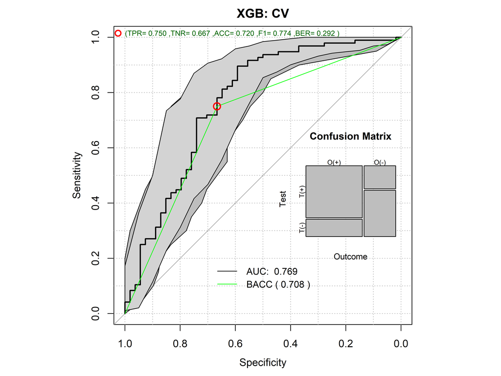

### 1.5.2 ILAA XGB

```r
ILAAXGBcv <- randomCV(fittingFunction = filteredFit,
                     trainSampleSets = XBOOSTcv$trainSamplesSets,
                     fitmethod = s3xgb,
                      filtermethod = NULL,
                    DECOR = TRUE,
                    DECOR.control=list(thr=thro)
                    )
```

……….10 Tested: 144 Avg. Selected: 640 Min Tests: 1 Max Tests: 9 Mean Tests: 4.444444 . MAD: 0.3485781

……….20 Tested: 149 Avg. Selected: 640 Min Tests: 1 Max Tests: 16 Mean Tests: 8.590604 . MAD: 0.3475457

……….30 Tested: 149 Avg. Selected: 640 Min Tests: 2 Max Tests: 23 Mean Tests: 12.88591 . MAD: 0.3437763

……….40 Tested: 150 Avg. Selected: 640 Min Tests: 1 Max Tests: 30 Mean Tests: 17.06667 . MAD: 0.3322035

……….50 Tested: 150 Avg. Selected: 640 Min Tests: 1 Max Tests: 38 Mean Tests: 21.33333 . MAD: 0.3293935

```r
ILAAXGBbs <- predictionStats_binary(ILAAXGBcv$medianTest,"ILAA-XGB: CV")
```

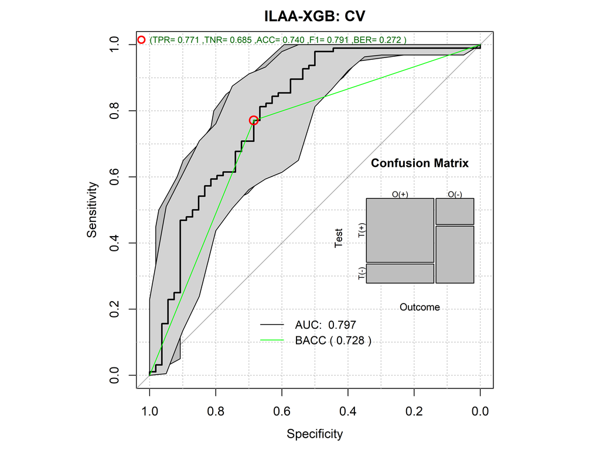

### 1.5.3 LASSO

```r
LASSOcv <- randomCV(fittingFunction = LASSO_MIN,
                     trainSampleSets = XBOOSTcv$trainSamplesSets,
                    family="binomial")
```

……….10 Tested: 144 Avg. Selected: 13.4 Min Tests: 1 Max Tests: 9 Mean Tests: 4.444444 . MAD: 0.3825302

……….20 Tested: 149 Avg. Selected: 13.85 Min Tests: 1 Max Tests: 16 Mean Tests: 8.590604 . MAD: 0.3848146

……….30 Tested: 149 Avg. Selected: 13.86667 Min Tests: 2 Max Tests: 23 Mean Tests: 12.88591 . MAD: 0.3875273

……….40 Tested: 150 Avg. Selected: 13.725 Min Tests: 1 Max Tests: 30 Mean Tests: 17.06667 . MAD: 0.3845017

……….50 Tested: 150 Avg. Selected: 14.44 Min Tests: 1 Max Tests: 38 Mean Tests: 21.33333 . MAD: 0.3821458

```r
LASSObs <- predictionStats_binary(LASSOcv$medianTest,"LASSO: CV")
```

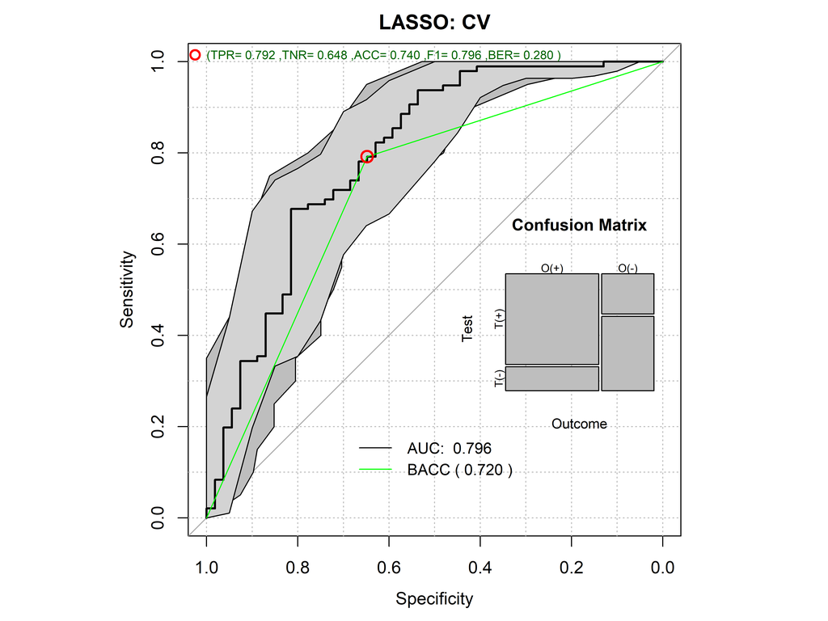

### 1.5.4 ILAA LASSO

```r
ILAALASSOcv <- randomCV(fittingFunction = filteredFit,
                     trainSampleSets = XBOOSTcv$trainSamplesSets,
                     fitmethod = LASSO_MIN,
                      filtermethod = NULL,
                    DECOR = TRUE,
                    DECOR.control=list(thr=thro),
                    family="binomial")
```

……….10 Tested: 144 Avg. Selected: 16.9 Min Tests: 1 Max Tests: 9 Mean Tests: 4.444444 . MAD: 0.409757

……….20 Tested: 149 Avg. Selected: 18.2 Min Tests: 1 Max Tests: 16 Mean Tests: 8.590604 . MAD: 0.4005286

……….30 Tested: 149 Avg. Selected: 17.9 Min Tests: 2 Max Tests: 23 Mean Tests: 12.88591 . MAD: 0.3948812

……….40 Tested: 150 Avg. Selected: 17.9 Min Tests: 1 Max Tests: 30 Mean Tests: 17.06667 . MAD: 0.3948272

……….50 Tested: 150 Avg. Selected: 17.72 Min Tests: 1 Max Tests: 38 Mean Tests: 21.33333 . MAD: 0.3949464

```r
ILAALASSObs <- predictionStats_binary(ILAALASSOcv$medianTest,"ILLA-LASSO: CV")
```

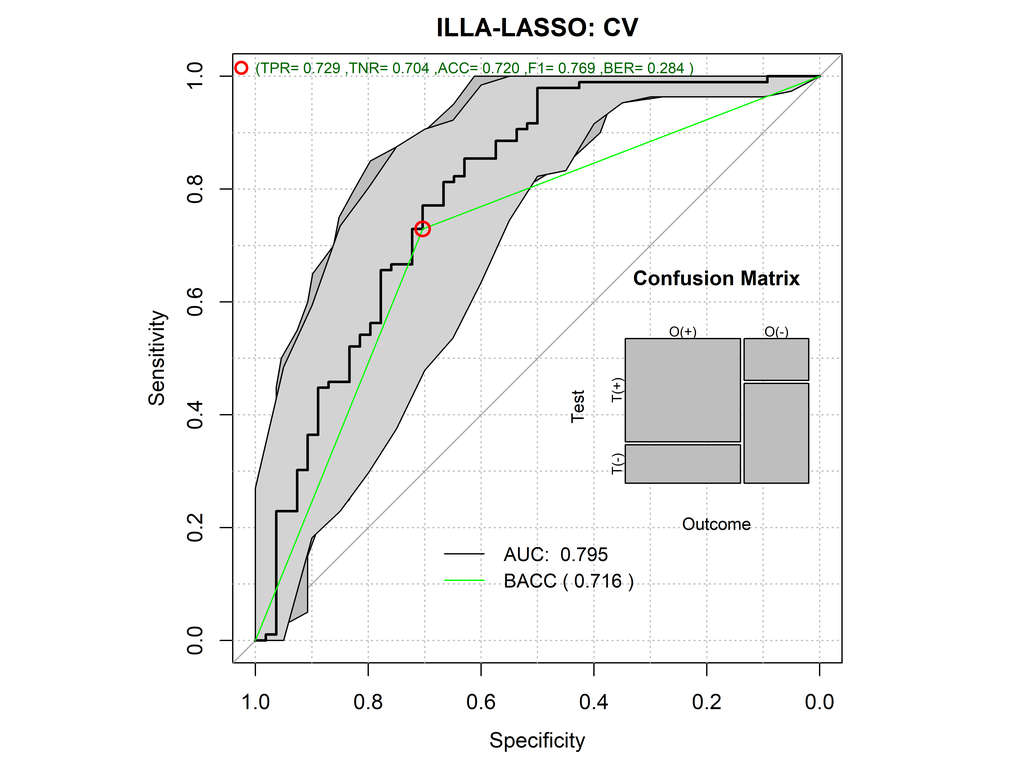

### 1.5.5 SVM

```r
SVMcv <- randomCV(fittingFunction = filteredFit,
                  trainSampleSets = XBOOSTcv$trainSamplesSets,
                  asFactor = TRUE,
                  filtermethod = multivariate_BinEnsemble,
                  filtermethod.control=NULL,
                  probability=TRUE)
```

……….10 Tested: 144 Avg. Selected: 32.5 Min Tests: 1 Max Tests: 9 Mean Tests: 4.444444 . MAD: 0.3440087

……….20 Tested: 149 Avg. Selected: 38.3 Min Tests: 1 Max Tests: 16 Mean Tests: 8.590604 . MAD: 0.3459081

……….30 Tested: 149 Avg. Selected: 37.36667 Min Tests: 2 Max Tests: 23 Mean Tests: 12.88591 . MAD: 0.3424732

……….40 Tested: 150 Avg. Selected: 37.2 Min Tests: 1 Max Tests: 30 Mean Tests: 17.06667 . MAD: 0.3421424

……….50 Tested: 150 Avg. Selected: 38.04 Min Tests: 1 Max Tests: 38 Mean Tests: 21.33333 . MAD: 0.3448106

```r
SVMbs <- predictionStats_binary(SVMcv$medianTest,"SVM: CV")
```

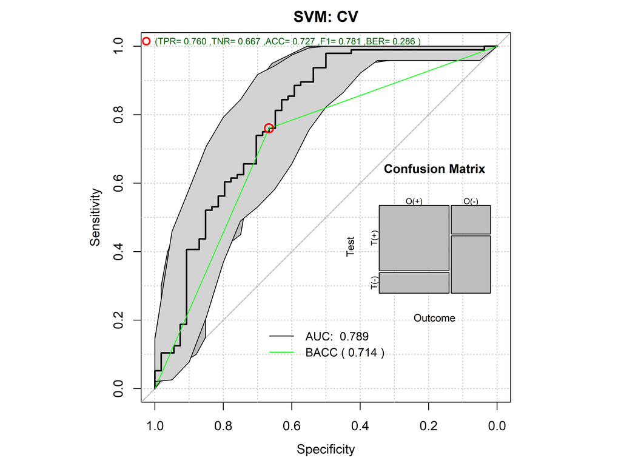

### 1.5.6 ILAAA SVM

```r
ILLASVMcv <- randomCV(dataframe,outcome,fittingFunction = filteredFit,
                  trainSampleSets = XBOOSTcv$trainSamplesSets,
                  asFactor = TRUE,
                  DECOR = TRUE,
                  DECOR.control=list(thr=thro),
                  filtermethod = multivariate_BinEnsemble,
                  filtermethod.control=NULL,
                  probability=TRUE)
```

…………….10 Tested: 144 Avg. Selected: 140.4 Min Tests: 1 Max Tests: 9 Mean Tests: 4.444444 . MAD: 0.3612393

……………….20 Tested: 149 Avg. Selected: 152.25 Min Tests: 1 Max Tests: 16 Mean Tests: 8.590604 . MAD: 0.3702852

……………..30 Tested: 149 Avg. Selected: 152.3333 Min Tests: 2 Max Tests: 23 Mean Tests: 12.88591 . MAD: 0.369349

………………40 Tested: 150 Avg. Selected: 149.225 Min Tests: 1 Max Tests: 30 Mean Tests: 17.06667 . MAD: 0.3701462

……………..50 Tested: 150 Avg. Selected: 148.64 Min Tests: 1 Max Tests: 38 Mean Tests: 21.33333 . MAD: 0.3702676

```r
ILLASVMbs <- predictionStats_binary(ILLASVMcv$medianTest,"ILLA-SVM: CV")
```

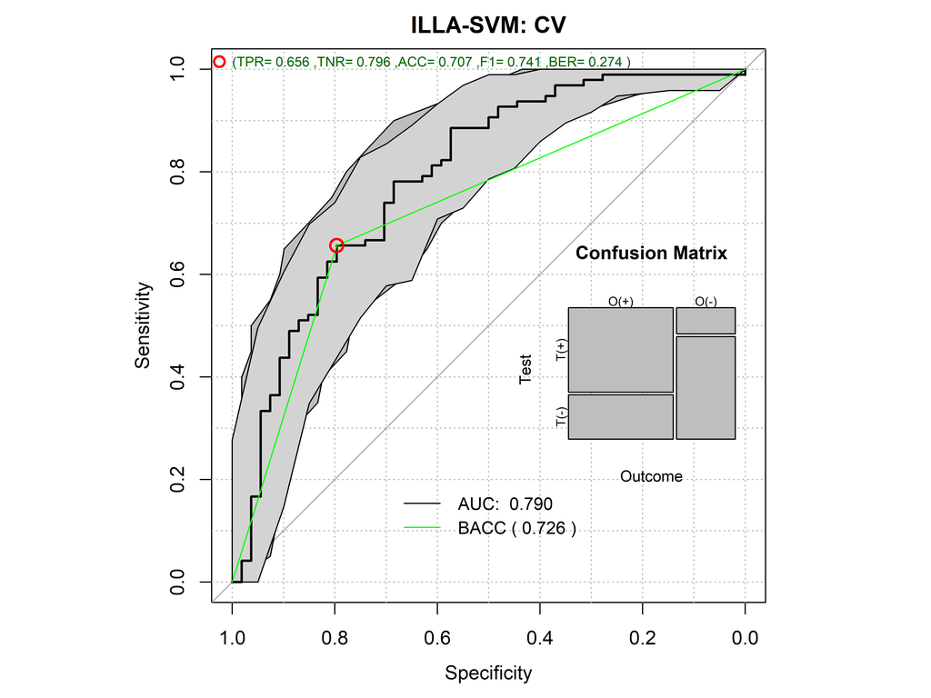

## 1.6 The Reports

```r
par(op)
AUCTABLE <- rbind(
                  XGBbs$aucs,
                  SVMbs$aucs,
                  LASSObs$aucs,
                  ILAAXGBbs$aucs,
                  ILLASVMbs$aucs,
                  ILAALASSObs$aucs
                  )
colnames(AUCTABLE) <- c("Median","Lower","Upper")
rownames(AUCTABLE) <- c("XGB","SVM","LASSO",
                        "ILAA-XGB","ILAA-SVM","ILAA-LASSO")

pander::pander(AUCTABLE)
```

|  | Median | Lower | Upper |
| --- | --- | --- | --- |
| **XGB** | 0.769 | 0.684 | 0.853 |
| **SVM** | 0.789 | 0.707 | 0.871 |
| **LASSO** | 0.796 | 0.716 | 0.875 |
| **ILAA-XGB** | 0.797 | 0.718 | 0.877 |
| **ILAA-SVM** | 0.790 | 0.712 | 0.869 |
| **ILAA-LASSO** | 0.795 | 0.714 | 0.875 |

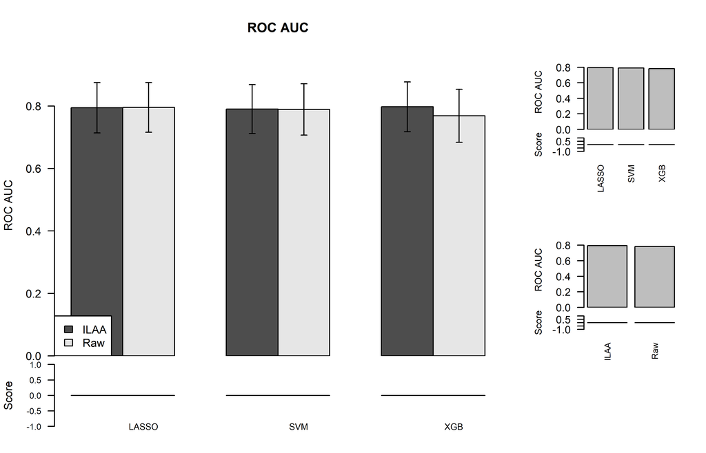

```r
thesets <- c("XGB","SVM","LASSO")
themethod <- c("Raw","ILAA")
pauc <- barPlotCiError(AUCTABLE,
               "ROC AUC",
               thesets=thesets,
               themethod=themethod,
               main="ROC AUC",
               angle=0,
               offsets=c(0.1,1.0),
               scoreDirection=">",args.legend=list(x="bottomleft"))

par(op)
```

```r
BERTABLE <- rbind(
                  XGBbs$berror,
                  SVMbs$berror,
                  LASSObs$berror,
                  ILAAXGBbs$berror,
                  ILLASVMbs$berror,
                  ILAALASSObs$berror
                  )


colnames(BERTABLE) <- colnames(AUCTABLE)
rownames(BERTABLE) <- rownames(AUCTABLE)

pander::pander(BERTABLE)
```

|  | Median | Lower | Upper |
| --- | --- | --- | --- |
| **XGB** | 0.291 | 0.217 | 0.373 |
| **SVM** | 0.285 | 0.210 | 0.364 |
| **LASSO** | 0.279 | 0.207 | 0.357 |
| **ILAA-XGB** | 0.270 | 0.197 | 0.348 |
| **ILAA-SVM** | 0.272 | 0.204 | 0.348 |
| **ILAA-LASSO** | 0.282 | 0.211 | 0.362 |

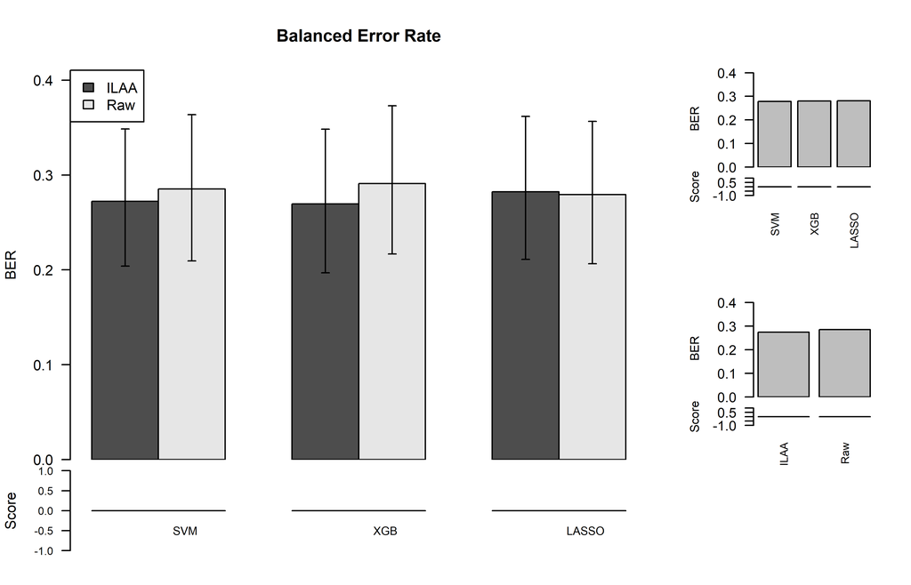

```r
pber <- barPlotCiError(BERTABLE,
               "BER",
               thesets=thesets,
               themethod=themethod,
               main="Balanced Error Rate",
               angle=0,
               offsets=c(0.1,0.5),
               scoreDirection="<",args.legend=list(x="topleft"))
```

### 1.6.1 Saving ALL

```r
save.image(paste("SOTACV_analyiss",studyName,".RData",sep="_"))
```